# L04 ggplot III

Data Visualization (STAT 302)

Noah Holubow

## Overview

The goal of this lab is to continue the process of unlocking the power of `ggplot2` through constructing and experimenting with a few basic plots.

## Datasets

We’ll be using data from the `blue_jays.rda`, `cows.rda`, and `cdc.txt` datasets which are already in the `/data` subdirectory in our **data_vis_labs** project.

```r
# Load package(s)
library(tidyverse)
library(dplyr)

# Load datasets

# Read in the cdc dataset
cdc <- read_delim(file = "data/cdc.txt", delim = "|") %>%
  mutate(genhlth = factor(genhlth,
    levels = c("excellent", "very good", "good", "fair", "poor")
  ))

# rad in blue jays dataset
load("data/blue_jays.rda")

# load in cows dataset
load("data/cows.rda")
```

Complete the following exercises.

### Exercise 1

Using `blue_jays.rda` dataset, recreate the following graphic as precisely as possible.

*Hints:*

- `geom_density_2d()` or `stat_density_2d()`
- Transparency is 1/3
- Horizontal lower limit is 57 and upper limit is 82
- Point size 1.5
- Line size is 0.4
- `binwidth` set to 0.004
- Minimal theme

**Answer:**

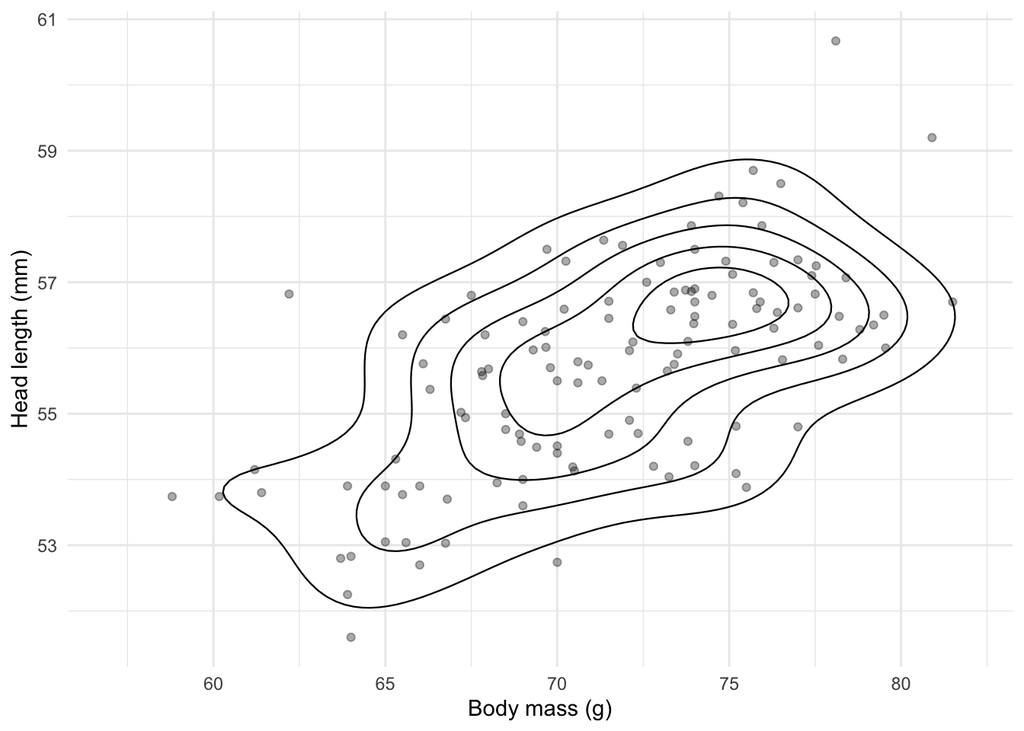

```r
# plot
blue_jays %>%
  ggplot(aes(Mass, Head)) +
  geom_density_2d(color = "black", size = 0.4, binwidth = 0.004) +
  xlim(57,82) +
  theme_minimal() +
  ylab("Head length (mm)") +
  xlab("Body mass (g)") +
  geom_point(alpha = 1/3, binwidth = 0.004)
```

### Exercise 2

Using `cdc` dataset, recreate the following graphics as precisely as possible.

#### Plot 1

*Hints:*

- `bins` set to 35
- Minimal theme

**Answer:**

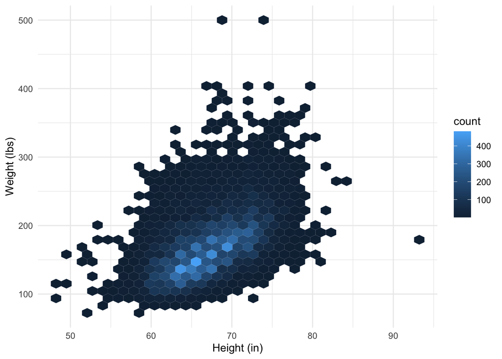

```r
# plot
base_plot <-
  ggplot(
    data = cdc, mapping = aes(x = height, y = weight)) +
  xlab("Height (in)") +
  ylab("Weight (lbs)") +
  theme_minimal()

cdc %>%
  ggplot(aes(height, weight)) +
  geom_hex(bins = 35) +
  xlab("Height (in)") +
  ylab("Weight (lbs)") +
  theme_minimal()
```

#### Plot 2

*Hints:*

- `polygon` (not a geom!)
- Minimal theme

**Answer:**

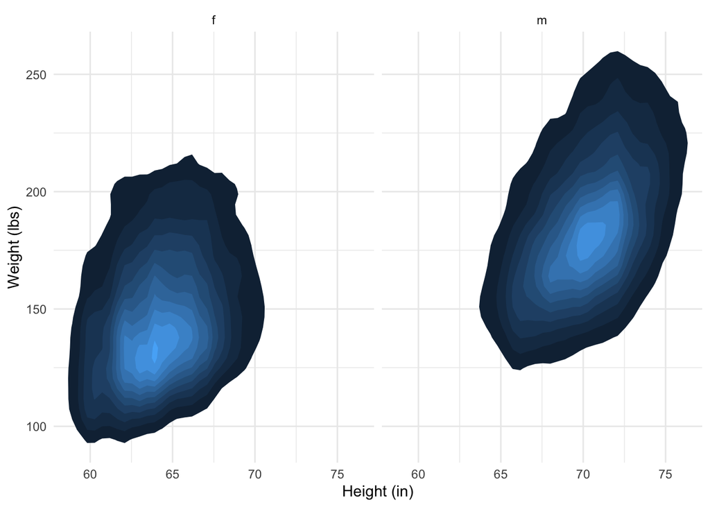

```r
# plot
base_plot +
  facet_wrap( ~ gender) +
  stat_density_2d(geom = "polygon", aes(fill = after_stat(level)),
show.legend = FALSE)
```

### Exercise 3

Using `cow_means` dataset derived from the `cows` dataset, recreate the following graphic as precisely as possible.

*Hints:*

- Hex color code `#56B4E9`
- 95% confidence intervals (1.96 or `qnorm(0.975)`)
- Some useful values: 0.1, 0.7

```r
# Graphic dataset
cow_means <- cows %>%
  filter(breed != "Canadian") %>%
  group_by(breed) %>%
  summarize(
    mean = mean(butterfat),
    se = sd(butterfat) / sqrt(n())
  ) %>%
  mutate(breed = fct_reorder(factor(breed), desc(mean)))
```

**Answer:**

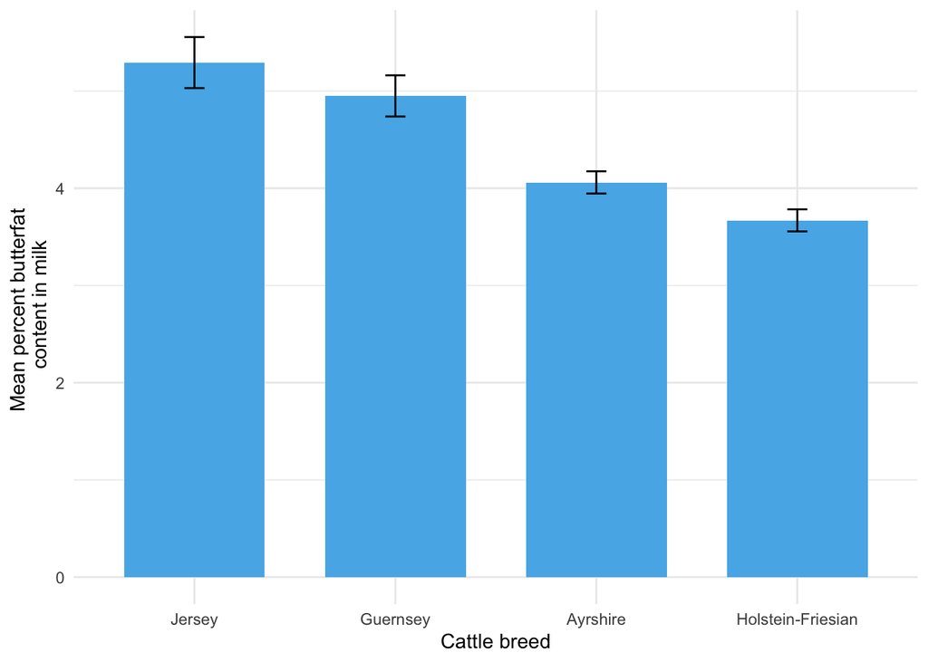

```r
# plot
cow_means %>%
  ggplot(aes(breed, mean)) +
  geom_col(fill = "#56B4E9", width = 0.7) +
  geom_errorbar(aes(ymin = mean - 1.96*se,
                    ymax = mean + 1.96*se),
                width = 0.1) +
  theme_minimal() +
  labs(
    x = "Cattle breed",
    y = "Mean percent butterfat \n content in milk"
  )
```

### Exercise 4

Using `cdc_weight_95ci` dataset derived from the `cdc` dataset, recreate the following graphic as precisely as possible.

*Hints:*

- Useful values: 0.1, 0.5

```r
# 95% CI for weight for genhlth, gender groups
cdc_weight_95ci <- cdc %>%
  group_by(genhlth, gender) %>%
  summarise(
    mean_wt = mean(weight),
    se = sd(weight) / sqrt(n()),
    moe = qt(0.975, n() - 1) * se
  )
```

**Answer:**

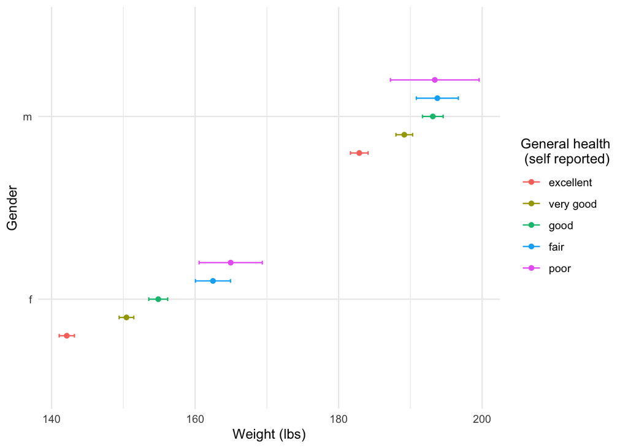

```r
# plot
cdc_weight_95ci %>%
  ggplot(aes(x = mean_wt, gender)) +
  geom_errorbar(aes(xmin = mean_wt - 1.96*se,
                    xmax = mean_wt + 1.96*se,
                    mean = moe,
                    color = genhlth),
                position = position_dodge(width = 0.5),
                width = 0.1) +
  geom_point(aes(x = mean_wt, color = genhlth),
           position = position_dodge(width = 0.5)) +
  labs(
    x = "Weight (lbs)",
    y = "Gender",
    color = "General health \n (self reported)"
  ) +
  theme_minimal()
```